# kreisberg_warblers

Aaron Kreisberg

12/10/2020

# Exploration of Black-Throated Blue Warblers at Hubbard Brook Experimental Forest, 1986-2010

## Set-up and Data Wrangling

### Set-up Code Chunk

Various packages are read in to support exploration and visualization of the black-throated blue warbler data

### Data Wrangling

Warbler data frame is wrangled using the filter() from the dplyr package

## Exploratory Data Visualizations

### Mass versus Wing Length

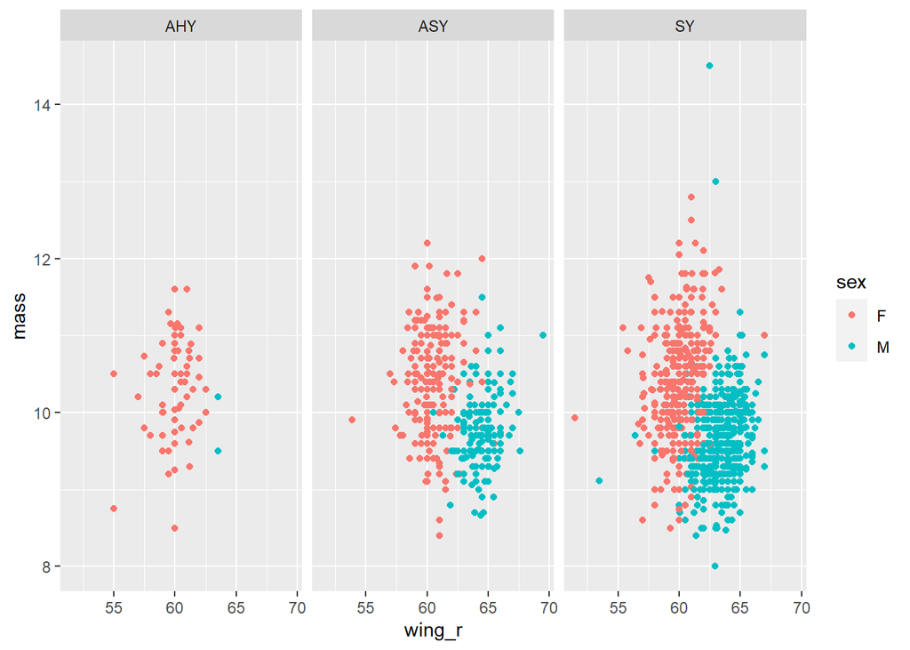

### Visualization II

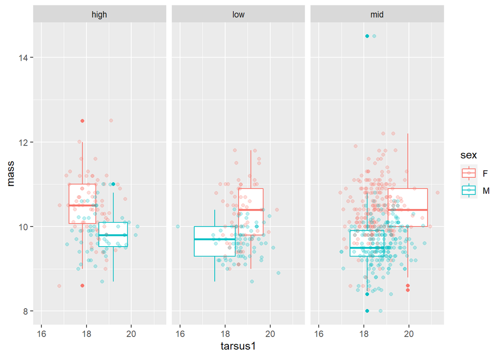

### Visualization III

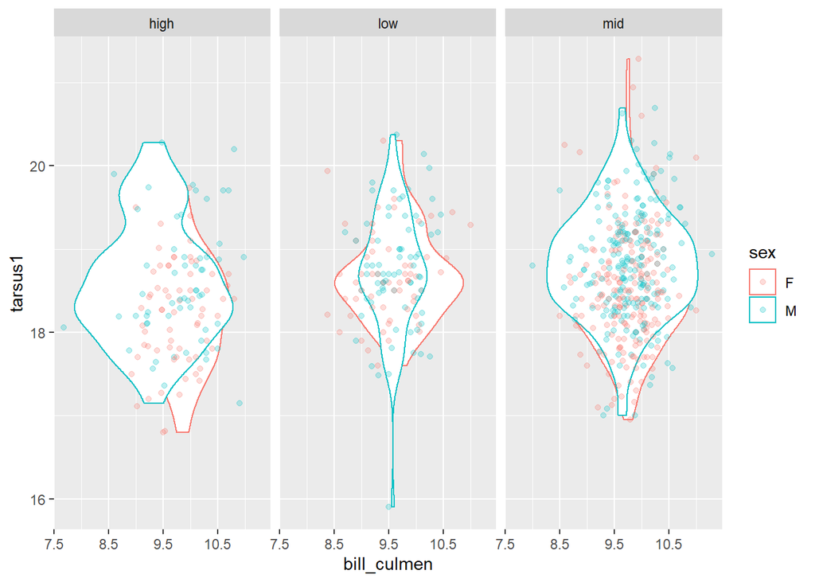

## Statistical Analysis and Diagnostics

### Model Fit

GGpairs() is used to explore distributions of various variables in the warbler data to ensure that data is normally distributed

### Akaike Information Criterion (AIC)

Multiple linear regression is performed under various scenarios and then models are assessed for fit using AIC

### Model Assumptions and Diagnostics

Assess model fit, residuals, and assumptions using plot() function for diagnostics

```
## [1] 1191.778
```

```
##
## Call:
## lm(formula = mass ~ wing_r + sex + bill_culmen + tarsus1, data = warblers_filtered)
##
## Residuals:
##     Min      1Q  Median      3Q     Max
## -1.7692 -0.3675 -0.0190  0.3678  4.8561
##
## Coefficients:
##             Estimate Std. Error t value Pr(>|t|)
## (Intercept)  3.59556    1.13934   3.156  0.00167 **
## wing_r       0.07085    0.01509   4.697 3.22e-06 ***
## sexM        -1.03383    0.06811 -15.179  < 2e-16 ***
## bill_culmen  0.14199    0.04691   3.027  0.00257 **
## tarsus1      0.06499    0.03353   1.939  0.05297 .
## ---
## Signif. codes:  0 '***' 0.001 '**' 0.01 '*' 0.05 '.' 0.1 ' ' 1
##
## Residual standard error: 0.5881 on 662 degrees of freedom
## Multiple R-squared:  0.3299, Adjusted R-squared:  0.3259
## F-statistic: 81.49 on 4 and 662 DF,  p-value: < 2.2e-16
```

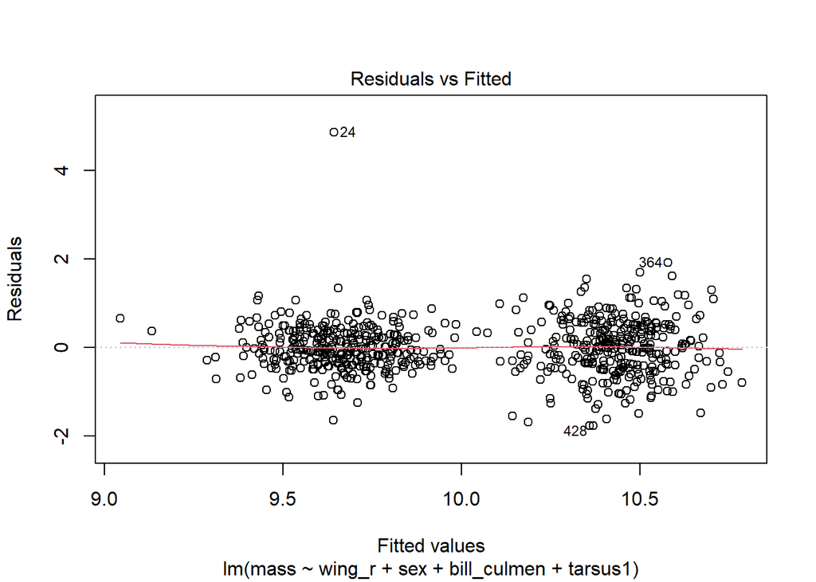

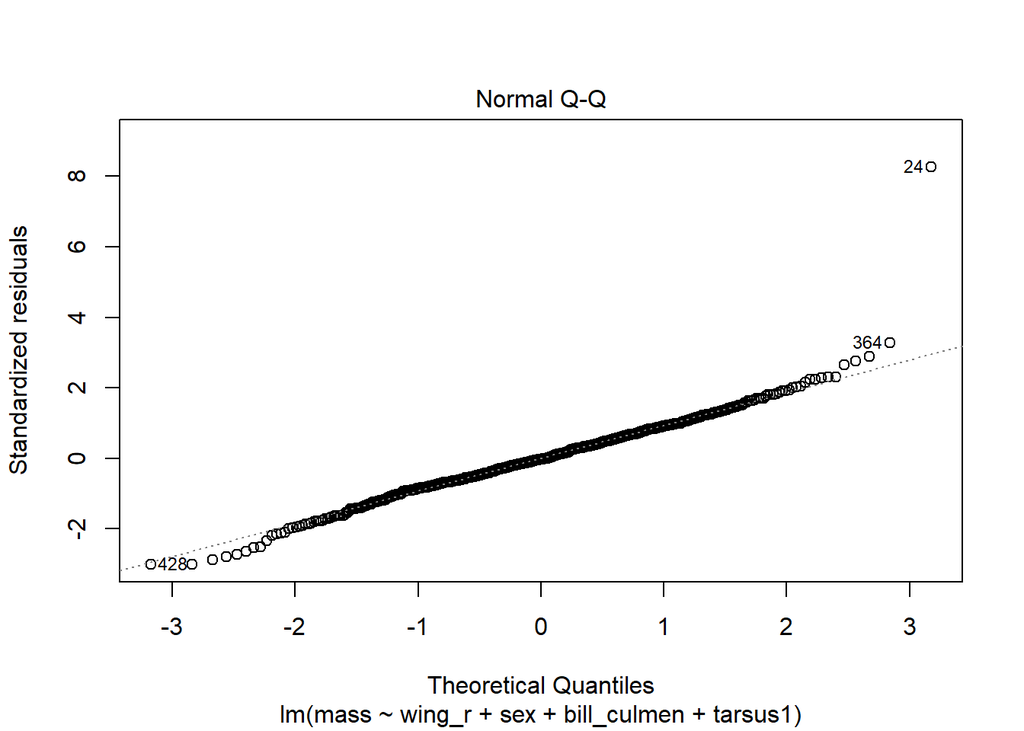

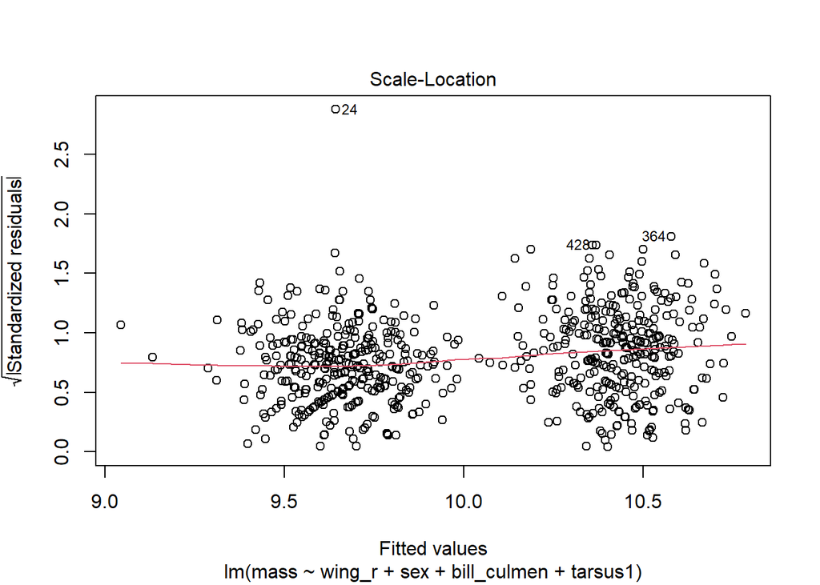

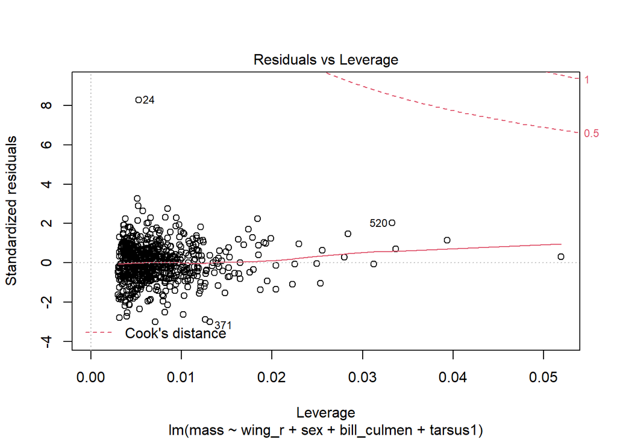

```
##      wing_r         sex bill_culmen     tarsus1
##    2.214304    2.235394    1.013604    1.050240
```

### Multiple Linear Regression

|  | *Dependent variable:* |
| --- | --- |
|  | mass |
| wing_r | 0.071*** |
|  | (0.015) |
| sexM | -1.034*** |
|  | (0.068) |
| bill_culmen | 0.142*** |
|  | (0.047) |
| tarsus1 | 0.065* |
|  | (0.034) |
| Constant | 3.596*** |
|  | (1.139) |
| Observations | 667 |
| R<sup>2</sup> | 0.330 |
| Adjusted R<sup>2</sup> | 0.326 |
| Residual Std. Error | 0.588 (df = 662) |
| F Statistic | 81.487*** (df = 4; 662) |
| *Note:* | p<0.1; p<0.05; p<0.01 |

Multiple linear regression is performed to create a model for warbler mass in relation to four variable: wing length (in millimeters), sex (male or female), culmen length (in millimeters), and tarsus length (in millimeters).

-AIC was used to determine the proper balance of model fit and variable, with the above mentioned multiple linear regression model yielding the lowest Akaike Information Criterion value (AIC = 1191.78). AIC is a relative measure and is useful in comparing models but needs to b used in conjunction with other assessments.

-When using pairs() to assess the assumptions of the model, all assumptions were met (residuals vs. fitted values/homoscedasticity, normal distribution of the residuals, and cook’s distance of residuals) although there is one warbler data point that is an outlier, a male warbler with a mass of 14.5 grams. Should also be conscious about interaction between predictor variables. Variance Inflation Factor (VIF) values show this to be less likely

### Discussion of Final Model

Mass = 3.596 + 0.071(wing_r) -1.034(Male) + 0.142(bill_culmen) + 0.065(tarsus1)

- **wing_r:** The coefficient of 0.071 for wing length (millimeters) indicates that on average, we expect a 0.071 gram increase in warbler mass for each additional millimeter in right wing length.
- **sex male:** The coefficient of -1.034 for males indicates that on average, if all other variables are equal, a male warbler’s mass to be 1.034 less than a female warbler. Female is the reference sex.
- **bill_culmen:** The coefficient of 0.142 for for bill culmen length (millimeters) indicates that on average, we expect a 0.142 gram increase in warbler mass for each additional millimeter of bill culmen length. The culmen goes from the tip of the bill to the feathers at top of head.
- **tarsus1 Value:**The coefficient of 0.065 for tarsus length (millimeters) indicates that on average, we expect a 0.065 gram increase in warbler mass for each additional millimeter of tarsus (foot) length.
- **Intercept Value:** The coefficient value (3.596) means that a female warbler with zero values for all the continuous explanatory variables would have a mass of 3.596 grams, which is not a very useful statement.

## Works Cited

- Rodenhouse, N., R. Holmes, S. Sillett, and M. Webster. 2019. Black-throated Blue Warbler capture histories, Hubbard Brook Experimental Forest, 1986 - 2010 ver 4. Environmental Data Initiative. https://doi.org/10.6073/pasta/ea985022acfdb76cd7beeaf8da6c39b1